# QTM 151 - Quiz 1

### Submit as an HTML or PDF file

### Print your name below

```python
# Write your answer here

print("Ahshar Brown")
```

### Instructions

This quiz is open book.

- You can use the lecture notes and the internet
- You will get partial credit for attempting the questions
- To get full credit, the code should your as intended
- You should NOT communicate with other students

Print the following message:

"I will abide by Emory's code of conduct"

```python
# Write your answer here:
print("I will abide by EMory's code of conduct")
```

### Import the libraries "numpy", "matplotlib.pytplot", and "pandas"

```python
# Write your answer here
import numpy as np
import matplotlib.pyplot as plt
import pandas as pd
```

### (a) Transform a list of values and plot it

- Create an array with the following values
- `vec_x = [-5,-3, 0, 10, 20, 40]`
- Create a new vector `vec_y` with the following formula
- $\qquad y = [cos(x)]^2$
- Produce a scatter plot of `vec_y` against `vec_x`
- Label the axes and the title
- Change the color to `red`, `green`, or `purple` (you choose)
- **Hint**: You can use the `numpy` functions

[figure not shown]

```python
# Write your answer here:
vec_x = np.array([-5, -3, 0, 10, 20, 40])
vec_y = np.cos(vec_x)**2


wdi = pd.DataFrame(vec_x)

# Scatter plot for vec_x vs vec_y
plt.scatter(x=vec_y, y=vec_x, color = "purple")
plt.ylabel("vec_x")
plt.xlabel("vec_y")
plt.title("Scatter plot of vec_x vs vec_y")
plt.show()
```

### (b) IF/ELSE statements

- Create two lists:
- `list_fruits = ["apple","orange","pear","banana"]`
- `list_colors = ["blue","red","green","orange"]`
- Create a new variable `message = "orange"`
- Create an if/else that tests whether `message` is a fruit and a color. Print a message if the test is true.
- **Hint**: Use the `in` command to test whether an element is part of a list (see Lecture 4)

```python
# Write your answer here:
list_fruits = ["apple", "orange", "pear", "banana"]
list_colors = ["blue", "red", "green","orange"]

message = "orange"

if (message in list_fruits) & (message in list_colors):
    print("Message is a fruit and a color")
elif (message in list_colors):
    print("Message is only a color")
elif (message in list_fruits):
    print("Message is only a fruit")
else:
    print("Message is neither a fruit or a color")
```

```
Message is a fruit and a color
```

### (c) Plot random variables

- Let $n = 1000$
- Generate `vec_x` from a Normal with (loc = 2, scale = 1, size = n)
- Generate `vec_z` from a chi square with (df = 2, size = n)
- Generate `vex_y` from a uniform with (low = 5,high = 10, size = n)
- Plot two scatter plots: (`vec_y` vs `vec_x`) and (`vec_z` vs `vec_x`)
  - Label the axes and title
  - Each graph should have a different title
- To get full points, plot the scatter plots on a single row using the `subplots` syntax (see Lecture 6)

[figure not shown]

[figure not shown]

```python
# Write your answer here:
n = 1000
vec_x = np.random.normal(loc = 2, scale = 1, size = n)

vec_z = np.random.chisquare(df = 2, size = n)

vec_y = np.random.uniform(low = 5,high = 10, size = n)

# Scatter plot for vec_x vs vec_y
plt.scatter(x=vec_y, y=vec_x)
plt.ylabel("vec_x")
plt.xlabel("vec_y")
plt.title("Scatter plot of vec_x vs vec_y")
plt.show()

# Scatter plot for vec_x vs vec_z
plt.scatter(x=vec_z, y=vec_x)
plt.ylabel("vec_x")
plt.xlabel("vec_z")
plt.title("Scatter plot of vec_x vs vec_z")
plt.show()
```

### (d) Create the following list of months:

`list_months = ["August","February"]`

`list_spring_semester = ["January", "February", "March", "April", "May"]`

Create a for-loop that checks whether each element of `list_months` belongs to the spring semester. Create a message with this result.

The output generated by your loop should look like this:

`"August is NOT part of the Spring semester"`

`"February is part of the Spring semester"`

- **Hint**: Use if/else statements inside the loop. You can use the command "in" (see Lecture 4) to test whether an element belongs to a list

```python
# Write your answer here:
list_months = ["August", "Feburary"]
list_spring_semester = ["January", "Feburary", "March", "April", "May"]

for i in list_months:
    if i in list_spring_semester:
        # Use f-string for formatting
        print(i +" " + "is part of the Spring Semester")
    else:
        # Proper string concatenation or f-string
        print(i + " " + "is not part of the Spring Semester")
```

```
August is not part of the Spring Semester
Feburary is part of the Spring Semester
```

### (e) Loop through dfferent variables and plot

- Read the dataset `data_quiz/wdi_ageprop_2020.csv`
- Create a list of variable names with the following elements:

`list_varnames = ["percent_ages0to14","percent_ages15to64"]`

- Run a for loop that creates a histogram plot for each of the variables on the list
- Label the axes (the y-axis can be called "Frequency")
- The loop should automatically create titles that look like this:
  - "Distribution for percent_ages0to14"
  - "Distribution for percent_ages15to64"

Note: This exercise tells you how much the proportion of the populaton in different ages varies across countries in 2020.

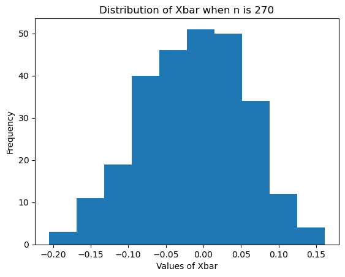

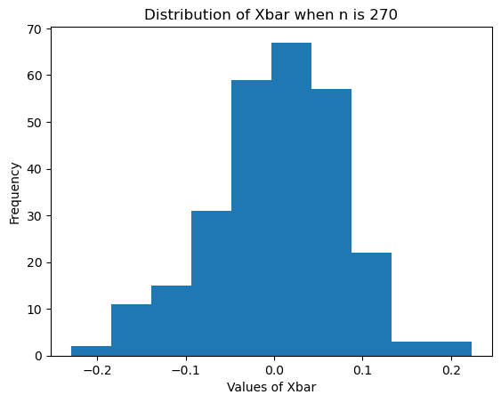

```python
# Write your answer here:
quiz = pd.read_csv('data_quiz/wdi_ageprop_2020.csv')
list_varnames = ["percent_ages0to14", "percent_ages15to64"]


for i in list_varnames:
    n = len(quiz[i])
    vec_xbar = []

    for iteration in range(n):
        vec_unif = np.random.uniform(low=-2, high=2, size=n)
        vec_xbar.append(vec_unif.mean())


    plt.hist(vec_xbar)
    plt.title(f"Distribution of Xbar when n is {n}")
    plt.ylabel("Frequency")
    plt.xlabel("Values of Xbar")
    plt.show()
```

### (f) Run loop through different datasets and compute statistics

- Create a list with the `.csv` dataset names (including their relative subfolder `data_quiz/`)
- Run a for-loop over the list of dataset names. Inside the loop:
  - Read the corresponding `.csv` dataset.
  - Print the mean of the variable `percent_ages0to14` in each dataset

Note: This exercise tells you how much the proportion of the population that is between 0 and 14 has varied from year to year using real data from the World Development Index.

```python
# Write your answer here:
quiz = pd.read_csv('data_quiz/wdi_ageprop_2020.csv')
list_varnames = ["percent_ages0to14", "percent_ages15to64"]


for quiz in list_varnames:
    data = pd.read_csv(quiz)
    mean_value = data['percent_ages0to14'].mean()
    print(f"The mean of 'percent_ages0to14' in {quiz} is: {mean_value}")
```

[output not shown]

[output cut: 10 more lines]

[output not shown]